# Investigating Data - Covid Wider Impacts

Looking at wider covid impacts data weekly variability - related to 2018/19 baseline

revised version - now extracting all Scotland more easily.

```r
library("tidyverse")
library("janitor")
```

```r
hb_codes <- read_csv("health_board_codes.csv")
hb_codes <- clean_names(hb_codes)
```

```r
weekly_admissions <- read.csv("Covid admissions by health board and speciality.csv")
weekly_admissions <- clean_names(weekly_admissions)
```

data cleaning

```r
weekly_admissions <- weekly_admissions %>%
  rename("speciality"= "specialty") %>%
  rename("speciality_qf"= "specialty_qf")
```

merge hbnames into data

```r
weekly_admissions <- left_join(weekly_admissions,hb_codes)
```

```r
weekly_admissions <- weekly_admissions %>%
  mutate(year = as.integer(str_sub(week_ending,1,4))) %>%
  mutate(month = as.integer(str_sub(week_ending,5,6))) %>%
  mutate(day = as.integer(str_sub(week_ending,7,8))) %>%
  mutate(wdate = ymd(week_ending)) %>%
  # identify "All Scotland" data
  mutate(hb_name = ifelse(hb=="S92000003","All Scotland",hb_name)) %>%
  mutate(hb_name = ifelse(is.na(hb_name),"NHS Region Unknown",hb_name)) %>%
  mutate(iswinter = ifelse(month %in% c(4,5,6,7,8,9),FALSE,TRUE)) %>%
  mutate(above_thresh = ifelse(percent_variation>0,7,0))
```

```r
weekly_admissions %>%
  distinct(hb_name)
```

| hb_name |
| --- |
| NHS Ayrshire and Arran |
| NHS Borders |
| NHS Dumfries and Galloway |
| NHS Forth Valley |
| NHS Grampian |
| NHS Highland |
| NHS Lothian |
| NHS Orkney |
| NHS Shetland |
| NHS Western Isles |

[output cut: 6 more lines]

```r
weekly_admissions %>%
  distinct(admission_type)
```

| admission_type |
| --- |
| All |
| Emergency |
| Planned |

```r
weekly_admissions %>%
  distinct(speciality)
```

| speciality |
| --- |
| Accident & Emergency |
| All |
| Cardiology |
| Medical (excl. Cardiology & Cancer) |
| Medical (incl. Cardiology & Cancer) |
| Paediatrics (medical & surgical) |
| Paediatrics (medical) |
| Surgery |
| Community |
| Gynaecology |

[output cut: 3 more lines]

calculate totals (just a sense check to see if adding all hb’s is the same as “all scotland”)

```r
total_admissions <- weekly_admissions %>%
  filter(admission_type == "All") %>%
  filter(speciality=="All") %>%
  filter(hb_name != "All Scotland") %>%
  group_by(wdate) %>%
  summarise(all_admissions = sum(number_admissions),
           all_avg20182019 = sum(average20182019)
           ) %>%
  mutate(all_percent_variation = (100*(all_admissions-all_avg20182019)/all_avg20182019)) %>%
  arrange(desc(all_admissions))
```

Now (just to check - extract same parameter using ‘all scotland’)

```r
total_admissions2 <- weekly_admissions %>%
  filter(admission_type == "All") %>%
  filter(speciality=="All") %>%
  filter(hb_name == "All Scotland")
```

plot calculated total admissions

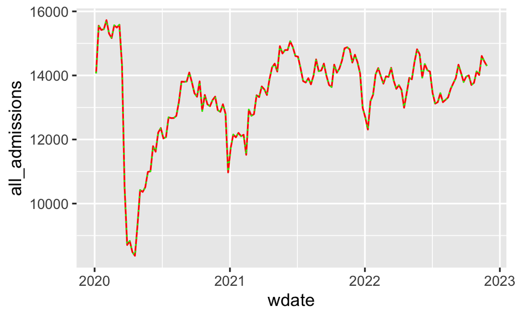

```r
total_admissions %>%
ggplot() +
aes(x=wdate, y = all_admissions) +
geom_line(colour='red') +
geom_line(aes(x=total_admissions2$wdate, y = total_admissions2$number_admissions),colour='green', linetype="dotted")
```

weekly hospital admissions hover around 14000 per week expect 168,000 per quarter?

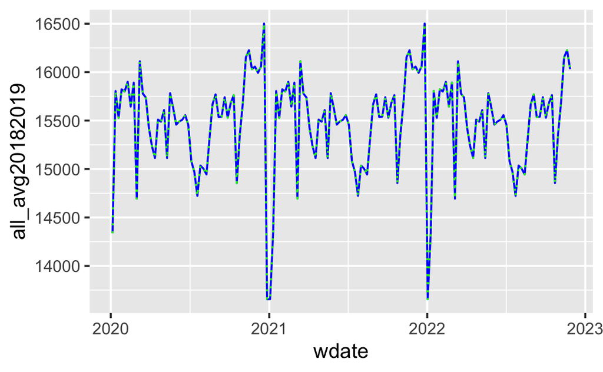

```r
total_admissions %>%
ggplot() +
aes(x=wdate, y = all_avg20182019) +
geom_line(colour='blue') +
geom_line(aes(x=total_admissions2$wdate, y = total_admissions2$average20182019),colour='green', linetype="dotted")
```

pre=pandemic hospital admissions hovered around 15500 per week expect 186,000 per quarter

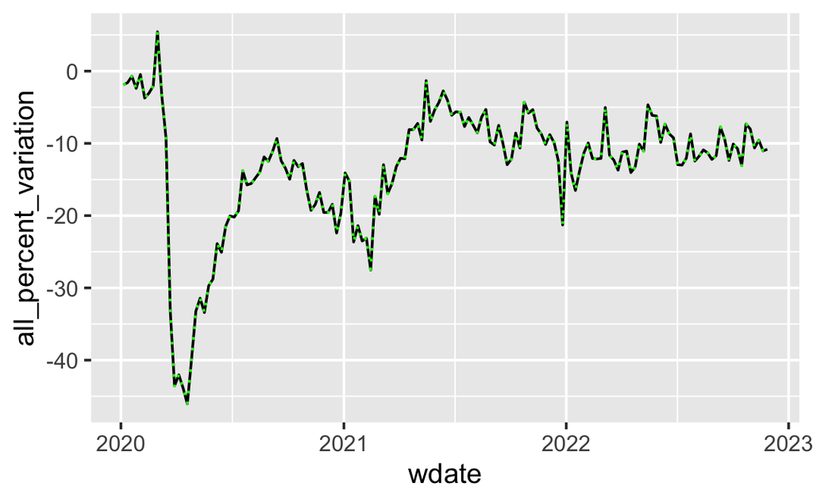

```r
total_admissions %>%
ggplot() +
aes(x=wdate, y = all_percent_variation) +
geom_line() +
geom_line(aes(x=total_admissions2$wdate, y = total_admissions2$percent_variation),colour='green', linetype="dotted")
```

Overall(all specialities, all admissions, all healthboards) admissions are only at 90% of pre-pandemic levels

The two lines sit over each other so shows that my calculations were correct. Can use these calculations when we dont have any averages.

Now look to see which health boards are struggling the most

```r
all_admissions_byhb <- weekly_admissions %>%
  filter(admission_type == "All") %>%
  filter(speciality=="All") %>%
  group_by(hb_name) %>%
  summarise(mean_percnt_var = mean(percent_variation),
            min_percnt_var = min(percent_variation),
            max_percnt_var = max(percent_variation)
           ) %>%
  #mutate(all_percent_variation = all_admissions/all_avg20182019)
  arrange(desc(max_percnt_var))
all_admissions_byhb
```

| hb_name | mean_percnt_var | min_percnt_var | max_percnt_var |
| --- | --- | --- | --- |
| NHS Shetland | -11.344079 | -58.4 | 64.9 |
| NHS Orkney | -4.790132 | -61.6 | 50.0 |
| NHS Region Unknown | -14.963816 | -59.4 | 37.6 |
| NHS Western Isles | -15.817763 | -55.8 | 27.9 |
| NHS Lothian | -7.321053 | -41.9 | 19.3 |
| NHS Borders | -22.176316 | -47.6 | 14.2 |
| NHS Tayside | -7.370395 | -40.6 | 12.0 |
| NHS Fife | -9.101316 | -47.7 | 10.3 |
| NHS Greater Glasgow and Clyde | -13.711842 | -47.4 | 9.3 |
| NHS Dumfries and Galloway | -13.994737 | -53.7 | 7.4 |

[output cut: 6 more lines]

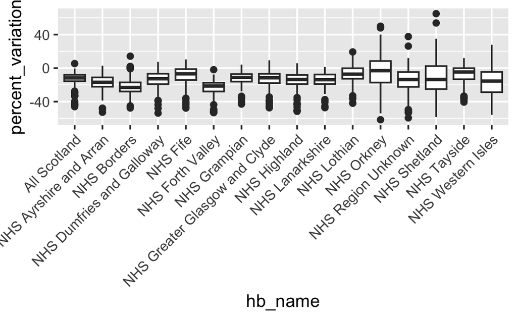

```r
weekly_admissions %>%
  filter(admission_type == "All") %>%
  filter(speciality=="All") %>%
  group_by(hb_name) %>%
  ggplot()+
  aes(x=hb_name, y=percent_variation)+
  geom_boxplot()+
  theme(axis.text.x = element_text(angle = 45, hjust = 1))
```

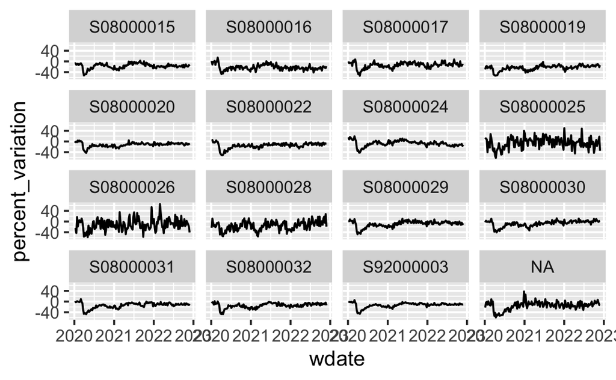

```r
weekly_admissions %>%
  filter(admission_type == "All") %>%
  filter(speciality=="All") %>%
  ggplot() +
  aes(x=wdate, y=percent_variation, group=hb) +
  geom_line()+
  facet_wrap(~hb)
```

What is S92000003 (found answer - its the code for “All Scotland”) How is NA calculated - still need to check??

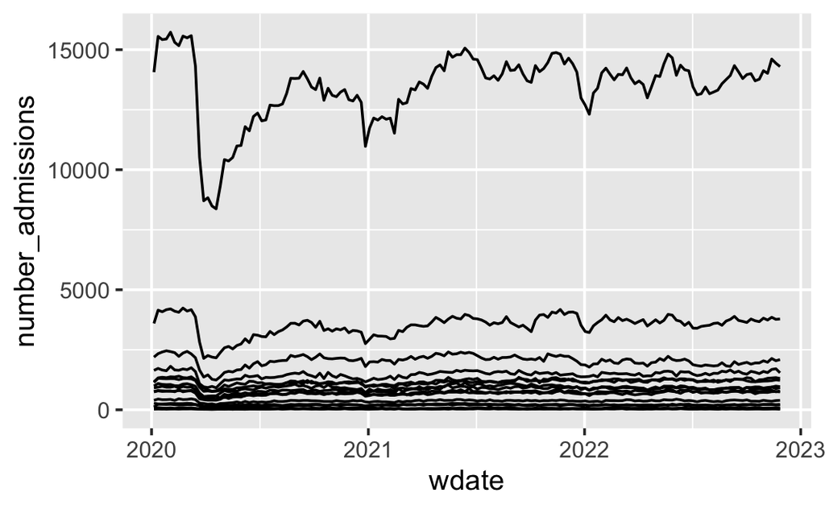

```r
weekly_admissions %>%
  filter(admission_type == "All") %>%
  filter(speciality=="All") %>%
ggplot() +
aes(x=wdate, y = number_admissions, group = hb) +
geom_line()
```

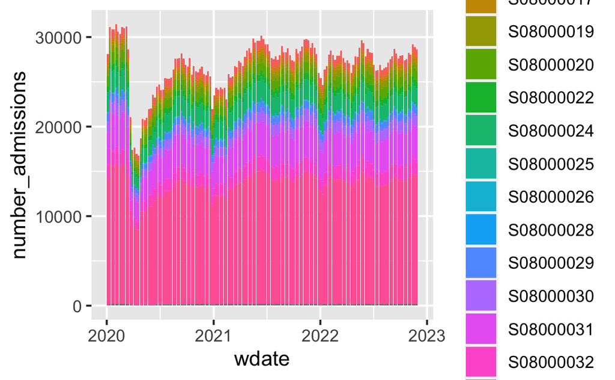

```r
weekly_admissions %>%
  filter(admission_type == "All") %>%
  filter(speciality=="All") %>%
ggplot() +
aes(x=wdate, y = number_admissions, fill=hb) +
geom_col()
```

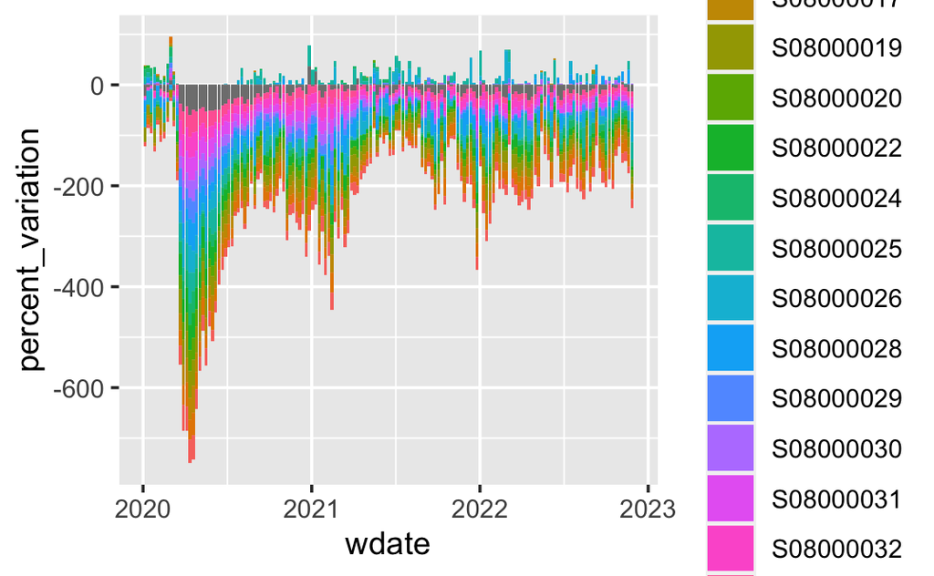

```r
weekly_admissions %>%
  filter(admission_type == "All") %>%
  filter(speciality=="All") %>%
ggplot() +
aes(x=wdate, y = percent_variation, fill=hb) +
geom_col()
```

? what about different departments?

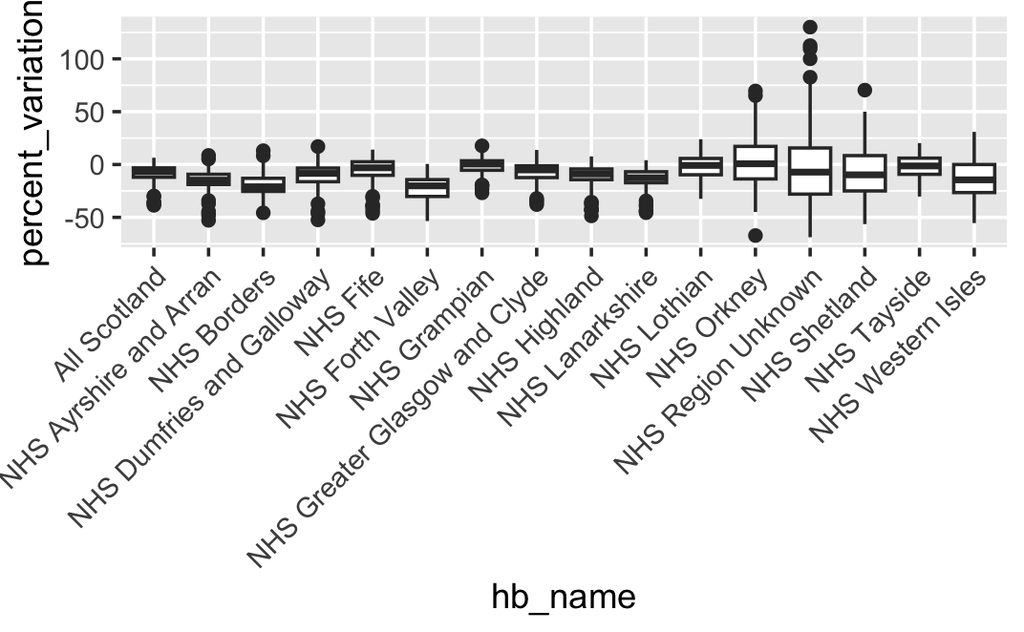

```r
weekly_admissions %>%
  filter(admission_type == "Emergency") %>%
  filter(speciality=="All") %>%
  group_by(hb_name) %>%
  ggplot()+
  aes(x=hb_name, y=percent_variation)+
  geom_boxplot()+
  theme(axis.text.x = element_text(angle = 45, hjust = 1))
```

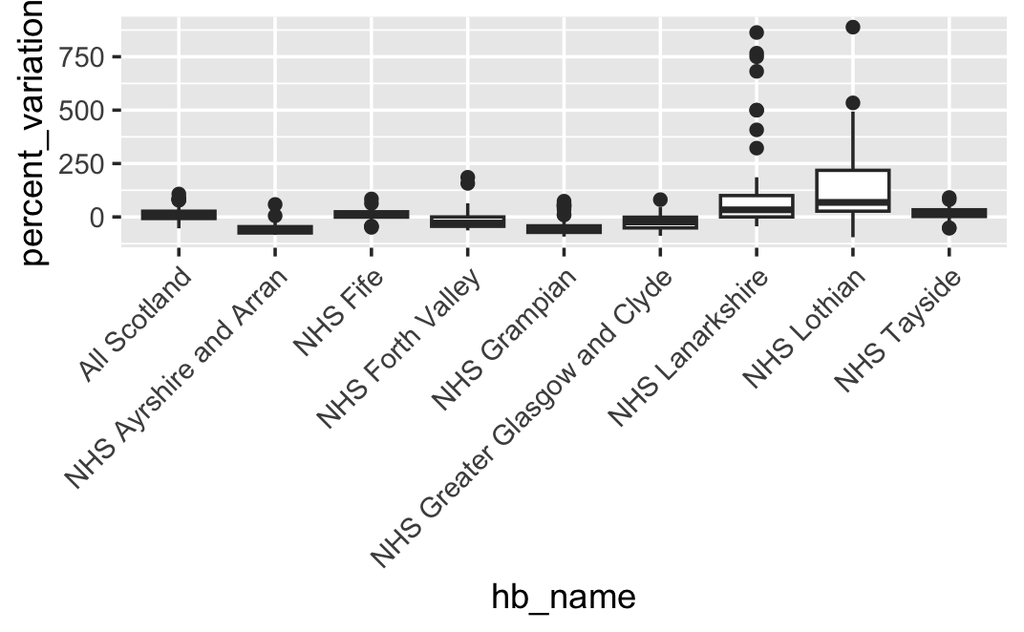

```r
weekly_admissions %>%
  filter(admission_type == "Emergency") %>%
  filter(speciality=="Accident & Emergency") %>%
 group_by(hb_name) %>%
  ggplot()+
  aes(x=hb_name, y=percent_variation)+
  geom_boxplot() +
  theme(axis.text.x = element_text(angle = 45, hjust = 1))
```

crisis calculator

```r
weekly_admissions %>%
  filter(admission_type == "All") %>%
  filter(speciality=="All") %>%
  filter(season =="Winter") %>%
ggplot() +
aes(x=wdate, y = number_admissions, fill=hb) +
geom_col()
```

[output not shown]